# HW1

```python
import numpy as np
import matplotlib.pyplot as plt
import seaborn as sns
import scipy.stats as sps
from scipy.stats import uniform
sns.set(style="darkgrid", font_scale=1.4)
plt.style.use("dark_background")
```

%symbols $\newcommand{\phi}{\varphi}$ $\newcommand{\kappa}{\varkappa}$ $\newcommand{\empty}{\varnothing}$ $\newcommand{\le}{\ \leqslant\ }$ $\newcommand{\ge}{\ \geqslant\ }$ $\newcommand{\d}{\partial}$ $\newcommand{\eps}{\varepsilon}$ $\newcommand{\grad}{\nabla}$ $\newcommand{\qed}{\hspace{1cm} \blacksquare}$ $\renewcommand{\E}[1]{\mathbb{E}\left[#1\right]}$ $\renewcommand{\V}[1]{\mathbb{V}\left[#1\right]}$

%braces $\renewcommand{\l}{\left}$ $\renewcommand{\r}{\right}$ $\newcommand{\la}{\left\langle}$ $\newcommand{\ra}{\right\rangle}$ $\newcommand{\lr}[1]{\left(#1\right)}$ $\newcommand{\lrsq}[1]{\left[#1\right]}$ $\newcommand{\lara}[1]{\left\langle#1\right\rangle}$ $\renewcommand{\t}{\hspace{0.5cm}}$

$\newcommand{\bb}[1]{\mathbb{#1}}$ $\renewcommand{\bf}[1]{\mathbf{#1}}$

$\newcommand{\tild}[1]{\widetilde{#1}}$ $\renewcommand{\hat}[1]{\widehat{#1}}$

$\newcommand{\ro}[1]{\rho\left(#1\right)}$ $\newcommand{\norm}[1]{\left\lVert#1\right\rVert}$ $\newcommand{\abs}[1]{\left|#1\right|}$

$\newcommand{\seq}[1]{\left\{#1_n\right\}_{n=1}^\infty}$ $\newcommand{\seg}[1]{\left[#1\right]}$

%arrows $\newcommand{\unifto}{\underset{n\rightarrow\infty}{\rightrightarrows}}$ $\newcommand{\to}{\underset{n\rightarrow\infty}{\longrightarrow}}$ $\newcommand{\tends}{\longrightarrow}$ $\newcommand{\nto}{\underset{n\rightarrow\infty}{\nrightarrow}} $\newcommand{\mapsto}{\longmapsto}$ $\newcommand{\Pthetato}{\overset{P_{\theta}}{\longrightarrow}}$

%limits $\newcommand{\lim}[3]{\underset{#1\rightarrow #2}{\text{lim}}#3}$ $\newcommand{\sup}[3]{\underset{#1\rightarrow #2}{\text{sup}}#3}$ $\newcommand{\inf}[3]{\underset{#1\rightarrow #2}{\text{inf}}#3}$ $\newcommand{\limsup}[3]{\underset{#1\rightarrow #2}{\text{limsup}}#3}$

# Задача №1.

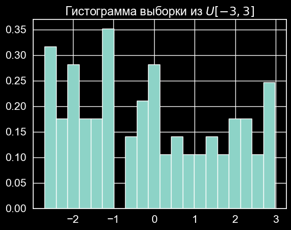

```python
theta = 3
n = 100
sample = uniform.rvs(-theta, 2*theta, size=n)
plt.hist(sample, density=True, bins=20)
plt.title("Гистограмма выборки из $U[{}, {}]$".format(-theta, theta))
pass
```

Вместо работы с $X_1, \ldots, X_n \sim \mathcal{U}[-\theta, \theta]$ рассмотрим задачу $X_1, \ldots, X_n \sim \mathcal{U}[0, \theta]$. Переход между такими задачами это просто сдвиг на $\theta$ вправо и $\dfrac{\theta}{2}$ влево соответственно. В случае равномерного распределения $X_1, \ldots, X_n \sim \mathcal{U}[0, \theta]$ для нахождения $\hat{\theta} = \underset{\theta \in \Theta}{argmax} f_\theta\lr{X_1, \ldots, X_n}$ продифференцировать функцию правдоподобия не получится, ведь функция плотности разрывна $$ f(x) = \begin{cases} \dfrac{1}{\theta},\hspace{0.5cm} x \in [0, \theta] ~\\ ~\\ 0, \hspace{1cm} x \in (-\infty, 0) \cup (\theta, +\infty) \end{cases} $$

Функция правдоподобия имеет вид $f_\theta\lr{X_1, \ldots, X_n} = \lr{\dfrac{1}{\theta}I\lr{0 \le X_1, \ldots, X_n \le \theta}}^n = \dfrac{1}{\theta^n}I\lr{0 \le X_1, \ldots, X_n \le \theta}$ Там, где $f_\theta$ не равна нулю, она равна некоторой константе $\dfrac{1}{\theta^n}$ , которую надо максимизировать, то есть надо минимизировать $\theta$. Но сделать её меньше $X_{(n)}$ не получится, так как иначе не выполнится условие под индикатором. Следовательно, $\hat{\theta} = X_{(n)}$ будет искомой ОМП. Получим функцию распределения статистики $\hat{\theta} = X_{(n)}$ :

$$P_{\theta}(X_i \le t) = \frac{t}{\theta}, \hspace{1cm} t \in [0, \theta]$$$$P(X_{(n)} \le t) = P(X_1 \le t, \ldots, X_n \le t) = P(X_1 \le t)\cdot \ldots \cdot P(X_n \le t) = \lr{\frac{t}{\theta}}^n$$

Проверим состоятельность нашей статистики, то есть $\forall \theta \in \Theta \quad \hat{\theta}_n \overset{P_{\theta}}{\longrightarrow} \theta$

Для $0 < \eps < \theta$ имеем $$P_\theta\lr{\abs{X_{(n)} - \theta} > \eps} = P_\theta\lr{X_{(n)} > \theta + \eps} + P_\theta\lr{X_{(n)} < \theta - \eps} = 0 + \lr{\dfrac{\theta - \eps}{\theta}}^n \to 0$$ $\qed$

# Задача №2

Во-первых, при $c < 1$ имеем $f(x) < c\cdot g(x) < g(x)$, но тогда $1 = \int_\mathbb{R} f(x) < \int_\mathbb{R} g(x) = 1$. Значит, $1 \le c$.

# Задача №3

$$X = \lr{X_1, X_2, \ldots} \sim Beta(\alpha, \beta)$$$$\E{X} = \dfrac{\alpha}{\alpha + \beta}, \qquad \V{X} = \dfrac{\alpha\beta}{(\alpha+\beta)^2(\alpha + \beta + 1)}$$

$$T_n = \dfrac{\sum_{i=0}^{n-1} X_i - n\E{X_1}}{\sqrt{n\V{X_1}}}$$

Из ЦПТ $$T_n \overset{d}{\underset{n\rightarrow\infty}{\longrightarrow}} \mathcal{N}(0,1)$$

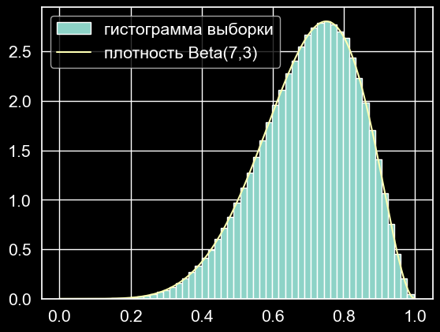

```python
alpha = 7
beta = 3
n = 1000000

E = alpha / (alpha + beta)
V = alpha * beta / ((alpha + beta + 1) * (alpha + beta)**2)

sample = sps.beta.rvs(alpha, beta, size=n)
plt.hist(sample, density=True, bins=50, label='гистограмма выборки')
plt.plot(np.linspace(0, 1, 1000), sps.beta.pdf(np.linspace(0, 1, 1000), alpha, beta), label='плотность Beta({},{})'.format(alpha, beta))
plt.legend()
pass
```

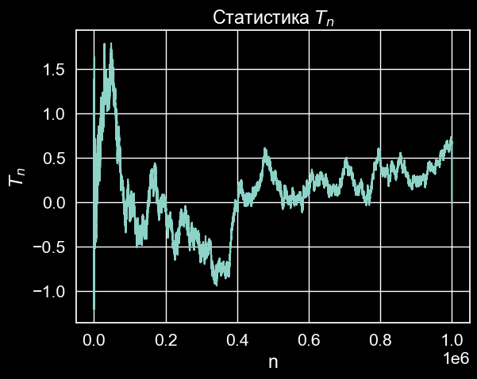

```python
def T_stat(m) :
    return (np.sum(sample[0:m]) - m*E) / np.sqrt(m*V)

T = np.zeros(n+1)
for i in range(1, n) :
    T[i] = (T[i-1] * np.sqrt((i-1)*V) + sample[i] - E) / np.sqrt(i*V)

plt.plot(T)
plt.title('Статистика $T_n$')
plt.xlabel('n')
plt.ylabel('$T_n$')
pass
```

Сходимости $T_n$ не наблюдается как минимум потому, что из ЦПТ мы знаем, что $$T_n \overset{d}{\underset{n\rightarrow\infty}{\longrightarrow}} \mathcal{N}(0,1)$$, то есть единственным возможным пределом последовательности статистик мог бы служить нуль, но по графику для большой выборки видно обратное

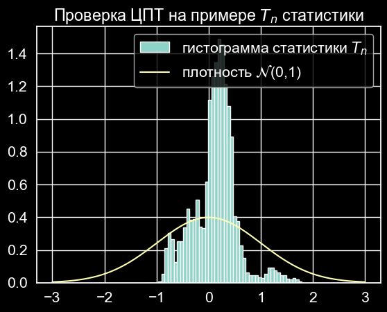

```python
plt.hist(x=T, density=True, bins=50, label='гистограмма статистики $T_n$')
plt.plot(np.linspace(-3, 3, 1000), sps.norm.pdf(np.linspace(-3, 3, 1000)), label='плотность $\mathcal{N}$(0,1)')
plt.title('Проверка ЦПТ на примере $T_n$ статистики')
plt.legend()
pass
```

# Задача №4

$$X = \lr{X_1, \ldots, X_{100}} \sim Pareto(\alpha, 1), \quad \alpha \in (0, 5)$$$$F_\alpha(t) = 1 - \dfrac{1}{t^\alpha}, \quad t \ge 1$$

Заметим, что в силу симметрии относительно ординаты $\dfrac{1}{2}$ имеем $1 - F_\alpha(t)$ распределена так же как и $F_\alpha(t)$ на $[0,1]$. В самом деле, $$1 - \dfrac{1}{t^\alpha} = \dfrac{1}{2} + \lr{\dfrac{1}{2} - \dfrac{1}{t^\alpha}}, \qquad \dfrac{1}{t^\alpha} = \dfrac{1}{2} - \lr{\dfrac{1}{2} - \dfrac{1}{t^\alpha}}$$ Поэтому статистика $$G(X, \alpha) = -\sum_{i=1}^n \log\lr{1-F_\alpha (X_i)} = \alpha \sum_{i=1}^n \log(X_i)$$ является центральной и распределена как $\Gamma(n,1)$. Откуда

$$\gamma = P_\alpha\lr{u_\frac{1-\gamma}{2} < G(X, \alpha) < u_\frac{1+\gamma}{2}} = P_\alpha\lr{u_\frac{1-\gamma}{2} < \alpha \sum_{i=1}^n \log(X_i) < u_\frac{1+\gamma}{2}} = P_\alpha\lr{\dfrac{u_\frac{1-\gamma}{2}}{\sum_{i=1}^n \log(X_i)} < \alpha < \dfrac{u_\frac{1+\gamma}{2}}{\sum_{i=1}^n \log(X_i)}}$$

где $u_p$ есть $p-$квантиль распределения $\Gamma(n,1)$.

[figure not shown]

```python
import warnings
warnings.filterwarnings("ignore")

precision = 0.95
n = 100
grid = 1 + np.arange(n)


def theta_hat(sample, theta):
    return theta * np.sum(np.log(sample))


def interval(sample, precision):
    lower = sps.gamma(a=n, scale=1).ppf((1 - precision)/2) / np.log(np.prod(sample))
    upper = sps.gamma(a=n, scale=1).ppf((1 + precision)/2) / np.log(np.prod(sample))
    return float(lower), float(upper)


plt.figure(figsize=(20, 10))
for i in range(1, 50, 7) :
    sample = sps.pareto.rvs(size=n, b=i/10)
    intervals = np.array([interval(sample[:n], precision) for n in grid])
    plt.fill_between(grid, intervals.T[0], intervals.T[1], alpha=0.5, label='$\\alpha={}$'.format(i))
    plt.title('Доверительный интервал параметра для $Pareto(\\alpha)$ для уровня доверия {}'.format(precision))
    plt.xlabel('размер выборки n')
    plt.ylabel('оценка $\widehat{\\alpha}$')
    plt.ylim(0, 20)
    plt.legend()
pass
```

# Задача №5

```python
alpha = 5
beta = 1
n = 100

def F(x, alpha, beta): # Weibull_cdf
    return 1 - np.exp(-(beta*x)**alpha)
```

Знаем, что $$F_\xi(\xi) \sim \mathcal{U}[0,1]$$ Откуда $$\xi \sim F_\xi^{-1}\lr{\mathcal{U}[0,1]}$$ В нашем случае $$F_\xi(x) = 1 - exp\lr{-(\beta x)^\alpha}, \quad x > 0,\ \alpha > 0,\ \beta > 0$$ То есть $$F^{-1}_\xi(t) = \dfrac{\sqrt[\alpha]{-\log(1 - t)}}{\beta}$$

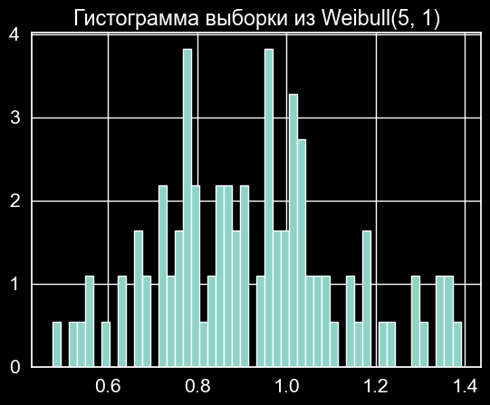

```python
def f(t, alpha, beta): # F^{-1}
    return np.power(-np.log(1-t), 1/alpha) / beta


sample = f(np.random.rand(n), alpha, beta)
plt.hist(sample, density=True, bins=50)
plt.title("Гистограмма выборки из Weibull({}, {})".format(alpha, beta))
pass
```

```python
X = sample.copy()
X.sort()
X
```

```
array([0.47471899, 0.51346676, 0.5376235 , 0.55133994, 0.55316764,
       0.60129919, 0.63688483, 0.63940511, 0.66053385, 0.66078092,
       0.6619969 , 0.67614413, 0.67985277, 0.71824375, 0.72164506,
       0.7284906 , 0.72877775, 0.73948312, 0.74425089, 0.75029827,
       0.7562172 , 0.76407172, 0.76962368, 0.77258932, 0.77464378,
       0.77798806, 0.77826003, 0.77950459, 0.7808538 , 0.79034424,
       0.79300192, 0.79893359, 0.799524  , 0.81013253, 0.827269  ,
       0.83701089, 0.8488593 , 0.84961003, 0.85134876, 0.85188827,
       0.863759  , 0.87053005, 0.87422895, 0.87454689, 0.88150397,
       0.88515537, 0.88768964, 0.89694686, 0.89841087, 0.91131379,
       0.91389223, 0.93663955, 0.94506693, 0.95279843, 0.95354387,
       0.96212643, 0.96346096, 0.96368989, 0.96807845, 0.96885268,
       0.97941641, 0.98234266, 0.98274535, 0.98801031, 0.99358733,
       1.00416677, 1.00832917, 1.01012482, 1.0178235 , 1.02116097,
       1.02195303, 1.0228004 , 1.02897043, 1.03227719, 1.03537316,
       1.03726083, 1.04062131, 1.04474162, 1.04586681, 1.06072684,
       1.06688041, 1.09167713, 1.09347921, 1.0984368 , 1.14006475,
       1.1450176 , 1.15233993, 1.17132424, 1.18334893, 1.18416109,
       1.22426602, 1.2349729 , 1.28199317, 1.28289939, 1.29873697,
       1.33586071, 1.35131263, 1.36005808, 1.36656087, 1.38994531])
```

Метод спейсингов: $$D_i(\theta) = F_\theta(X_{i+1}) - F_\theta(X_{i}),\quad i=0,\ldots,n, \quad X_{0} := -\infty, X_{n+1} := +\infty$$ $$\hat{\theta} = arg\max_\theta{\sum_{i=0}^n \log D_i(\theta)}$$

```python
def spacing_method(params):
    a = params[0]
    b = params[1]
    D = np.zeros(n+1)
    D[0] = F(X[0], a, b) - 0
    D[n] = 1 - F(X[n-1], a, b)
    for i in range(1, n):
        D[i] = F(X[i], a, b) - F(X[i-1], a, b)
    return -np.sum(np.log(D))
```

```python
from scipy.optimize import minimize
res = minimize(spacing_method, x0=[3,1])
res
```

```
  message: Optimization terminated successfully.
  success: True
   status: 0
      fun: 524.7186270832207
        x: [ 4.714e+00  9.947e-01]
      nit: 12
      jac: [ 0.000e+00  0.000e+00]
 hess_inv: [[ 2.880e-02  5.830e-04]
            [ 5.830e-04  4.038e-04]]
     nfev: 60
     njev: 20
```

Наблюдаем достаточно точный ответ. Метод хорошо показал себя применительно к данной задаче.